# Homework 07: Automating Data-analysis Pipelines

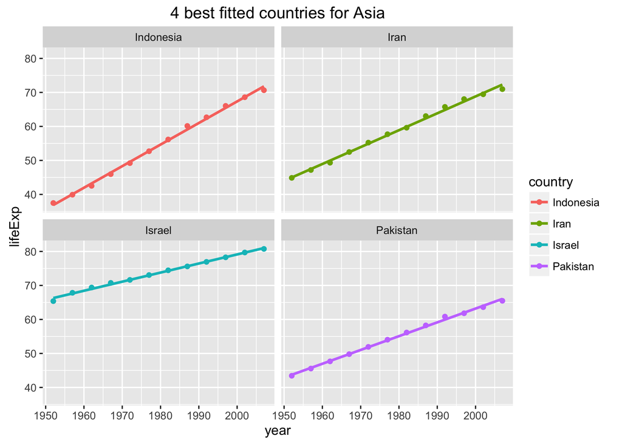

4. Europe

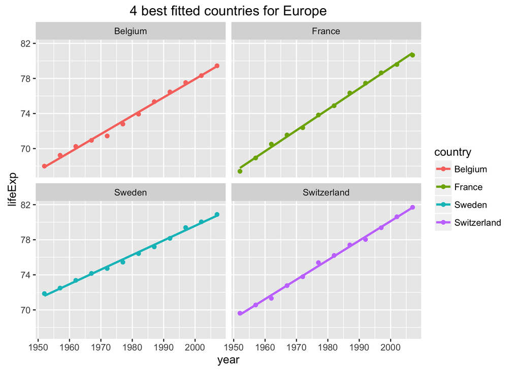

5. Oceania

[figure not shown]

## Automate the pipeline

```
all: report.html

clean:
    rm -f *.tsv *.png *.csv report.md *.html

gapminder.tsv: 00_download-the-data.R
    Rscript 00_download-the-data.R

exploratory_analyses: 01_perform-exploratory-analyses.R gapminder.tsv
    Rscript 01_perform-exploratory-analyses.R

statistical_analyses: 02_perform-statistical-analyses.R exploratory_analyses
    Rscript 02_perform-statistical-analyses.R

figures: 03_generate-figures.R statistical_analyses gapminder.tsv
    Rscript 03_generate-figures.R

report.html: report.Rmd figures
    Rscript 04_report.R
```

After I finished writing the five R scripts and this R markdown file, I automated the pipeline using make. The content of the Makefile is shown above.

## Report my process

Before I started doing this homework, I knew little about pipline. The examples given by the homework page are really useful. I just followed these examples to get the ideas about how to pipeline my R scripts. The links provided are also helpful. I encountered an error that "pandoc version 1.12.3 or higher is required and was not found (see the help page ?rmarkdown::pandoc_available)" when I rendered a R markdown file using make. Fortunately, I fixed it by googling the solution. I just got the path of pandoc using *`Sys.setenv(RSTUDIO_PANDOC)`* and set the path of pandoc using *`Sys.setenv(RSTUDIO_PANDOC = the path)`*.

## Some usefult links

- [An example of a data analysis pipeline using Make](https://github.com/sjackman/makefile-example/)
- [Automating Data Analysis Pipelines](http://sjackman.ca/makefile-slides/#/automating-data-analysis-pipelines)
- [An introduction to Make](http://kbroman.org/minimal_make/)
- makefile2graph
- [Homebrew](http://brew.sh)